# Titles, Labels, Axes, and more in ggplot2

February 03, 2020

## Preliminaries

Let’s start with a plot from the babynames package. To make the following code simpler, we can give the plot a name:

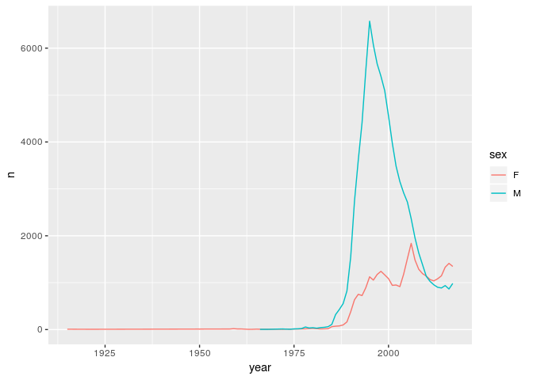

```r
library(tidyverse)
library(babynames)

dakota <- ggplot(data = filter(babynames, name == "Dakota")) +
     geom_line(mapping = aes(year, n, colour = sex))
# Note: the plot will not "print" unless you type the name
# or enclose the whole line in parentheses
dakota
```

## Titles in ggplot2

This one’s easy:

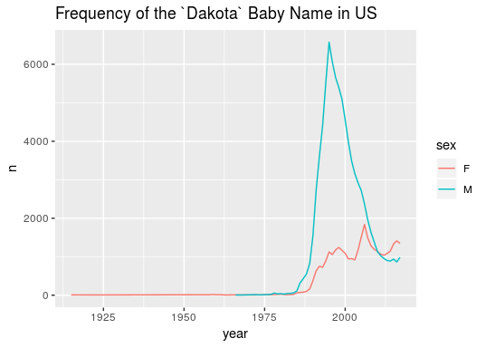

```r
dakota + ggtitle("Frequency of the `Dakota` Baby Name in US")
```

- If you’d rather have your title centered, add

```
+ theme(plot.title = element_text(hjust = 0.5))
```

## Axes labels

You can customize the label on either axis or both

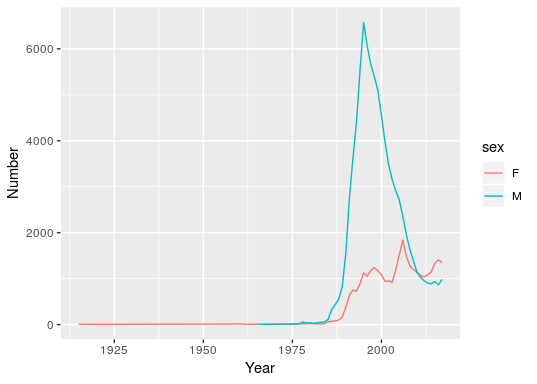

```r
dakota + xlab("Year") + ylab("Number")
```

## Legends

There is not a single function to adjust the legend (as there is in base R), since the legend is tied to the data and the aesthetics. We will return to this, but for now here are some common adjustments.

Eliminate the legend:

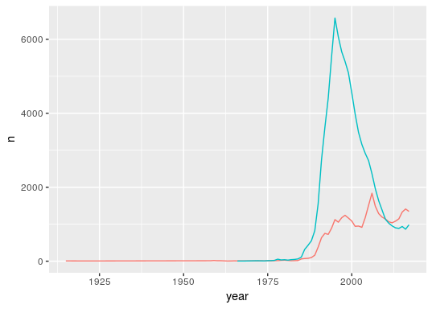

```r
dakota + theme(legend.position = "none")
```

Drop the title of the legend:

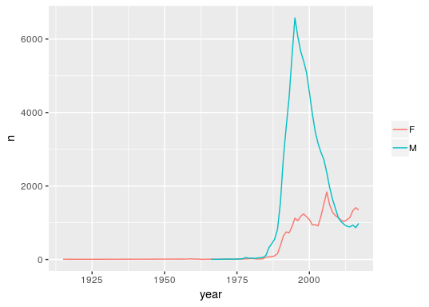

```r
dakota + theme(legend.title = element_blank())
```

Change the title of the legend:

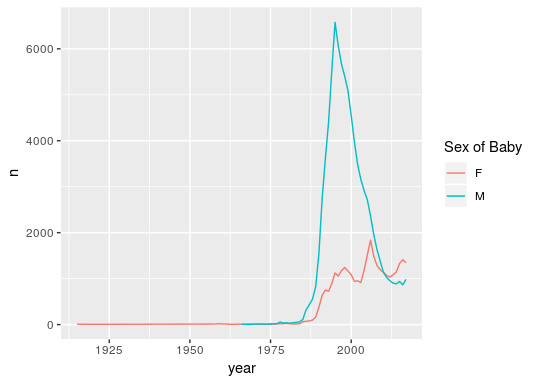

```r
dakota + scale_colour_discrete(name = "Sex of Baby")
```

The function name will vary depending on whether the data is discrete or continuous, and whether the legend is about the color of a line or fill.

Change the key labels of the legend (note that there’s no error checking to be sure that the label order is correct):

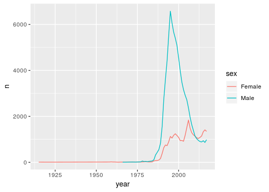

```r
dakota + scale_colour_discrete(labels = c("Female", "Male"))
```

## Change of scale for axis

To zoom in just add `coord_cartesian(xlim = c(1980, 2016))` or something analogous for the y-axis, using `ylim`, or both

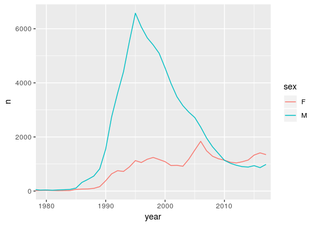

```r
dakota + coord_cartesian(xlim = c(1980, 2016))
```

## Putting it all together

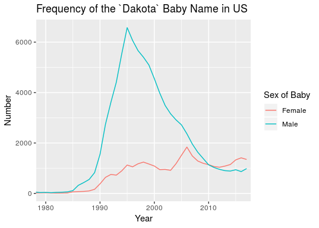

```r
dakota + ggtitle("Frequency of the `Dakota` Baby Name in US") +
  xlab("Year") + ylab("Number") +
  scale_colour_discrete(labels = c("Female", "Male"), name = "Sex of Baby") +
  coord_cartesian(xlim = c(1980, 2016))
```

```r
    # Note that the two scale_colour_discrete options are combined into one statement
```

## Labeling individual points

First, we’ll switch an example from the gapminder dataset

```r
library(gapminder)
gap_plot <- ggplot(data = filter(gapminder, year == 2007),  aes(gdpPercap, lifeExp)) +
  geom_point(aes(colour = continent, size = pop)) +
  scale_x_log10() + geom_smooth()
biggest_pop <- filter(gapminder, year == 2007, pop > 100000000)
```

## Using geom_text

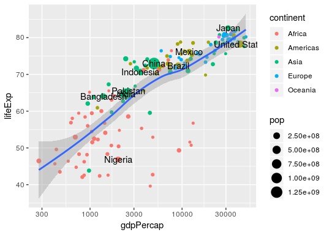

```r
gap_plot + geom_text(aes(label = country), data = biggest_pop)
```

## Using geom_label

The `alpha` option in `geom_label` controls the transparency. There is also a `nudge` option that can be useful

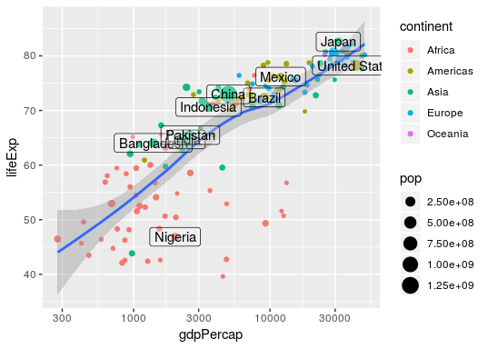

```r
gap_plot + geom_label(aes(label = country), data = biggest_pop, alpha = .25)
```

## Using the ggrepel package

In the ggrepel package, there is a nice function `geom_label_repel`. You can either load that package, or just call the function directly, without the rest of the package, using `ggrepel::geom_label_repel`. In either case, though, the package must be installed

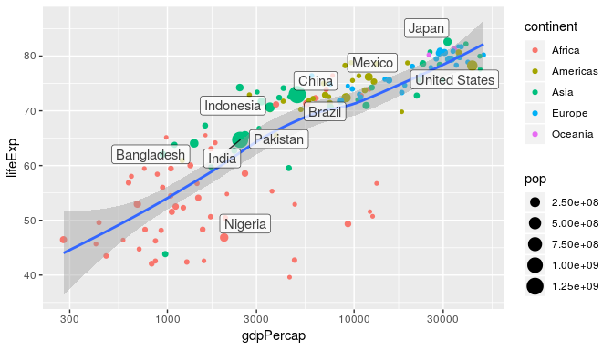

```r
gap_plot +
  ggrepel::geom_label_repel(aes(label = country), data = biggest_pop, alpha = .75)
```

## Interactive labeling

The `plotly` package includes a `ggploty` function to convert the plot to an interactive plot.

```r
library(plotly)
gap_plot +
  geom_point(aes(colour = continent, size = pop, label = country))
```

```r
ggplotly()
```

[interactive chart not shown]

## In class exercises

1. Using the nycflights13 data, plot schedule departure time against departure delays using all three airports in the same panel, but restricting to September 12, 2013. Add a title, new labels for the axis, a new name for the legend, and new key labels.
2. Using the 2007 gapminder data,
   - add a title and axis labels to the figure.
   - restrict the figure to countries with life expectancy over 75 (restrict the horizontal axis in some reasonable way)
   - label every country with population over 35 million in that plot